# Machine Learning in the Tidyverse

## Augment the fitted values of each model

Now you will prepare your four best and worst fitting models for further exploration by augmenting your model data with augment().

```r
best_augmented <- best_fit %>%
  # Build the augmented dataframe for each country model
  mutate(augmented = map(model, ~augment(.x))) %>%
  # Expand the augmented dataframes
  unnest(augmented)

worst_augmented <- worst_fit %>%
  # Build the augmented dataframe for each country model
  mutate(augmented = map(model, ~augment(.x))) %>%
  # Expand the augmented dataframes
  unnest(augmented)
```

## Explore your best and worst fitting models

Let’s explore your four best and worst fitting models by comparing the fitted lines with the actual values.

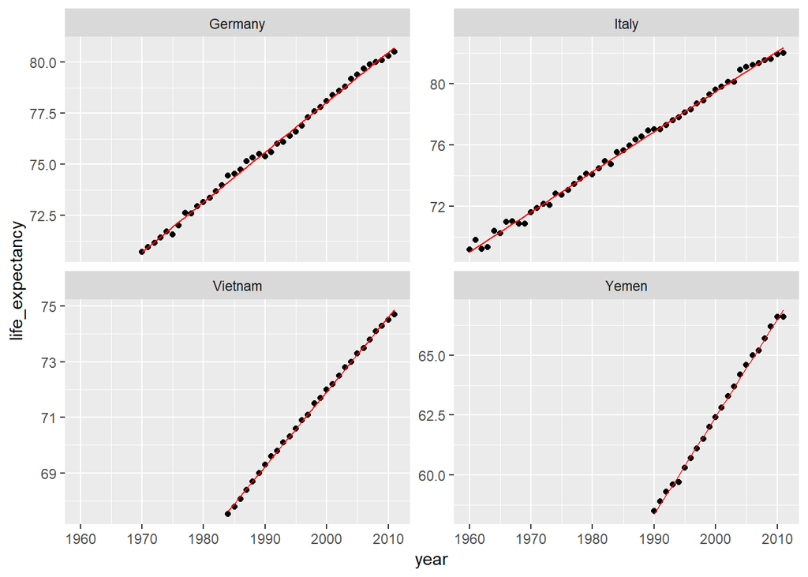

```r
# Compare the predicted values with the actual values of life expectancy
# for the top 4 best fitting models
best_augmented %>%
  ggplot(aes(x = year)) +
  geom_point(aes(y = life_expectancy)) +
  geom_line(aes(y = .fitted), color = "red") +
  facet_wrap(~country, scales = "free_y")
```

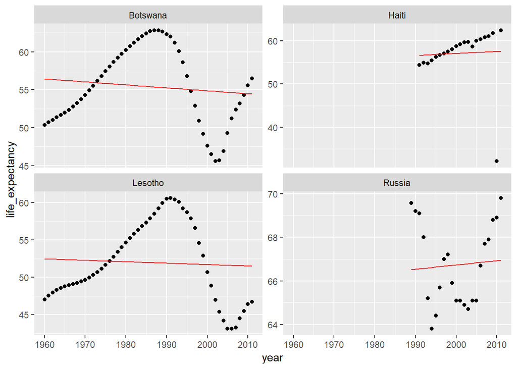

```r
# Compare the predicted values with the actual values of life expectancy
# for the top 4 worst fitting models
worst_augmented %>%
  ggplot(aes(x = year)) +
  geom_point(aes(y = life_expectancy)) +
  geom_line(aes(y = .fitted), color = "red") +
  facet_wrap(~country, scales = "free_y")
```

## Build better models

Earlier you built a collection of simple models to fit life expectancy using the year feature. Your previous analysis showed that some of these models didn’t fit very well.

The test-train split

In a disciplined machine learning workflow it is crucial to withhold a portion of your data (testing data) from any decision-making process. This allows you to independently assess the performance of your model when it is finalized. The remaining data, the training data, is used to build and select the best model.

In this exercise, you will use the rsample package to split your data to perform the initial train-test split of your gapminder data.

Note: Since this is a random split of the data it is good practice to set a seed before splitting it.

```r
set.seed(42)

# Prepare the initial split object
gap_split <- initial_split(gapminder, prop = .75)

# Extract the training dataframe
training_data <- training(gap_split)

# Extract the testing dataframe
testing_data <- testing(gap_split)

# Calculate the dimensions of both training_data and testing_data
dim(training_data)
```

```
## [1] 5355    9
```

```r
dim(testing_data)
```

```
## [1] 1784    9
```

## Cross-validation dataframes

Now that you have withheld a portion of your data as testing data, you can use the remaining portion to find the best performing model.

In this exercise, you will split the training data into a series of 5 train-validate sets using the vfold_cv() function from the rsample package.

```r
set.seed(42)

# Prepare the dataframe containing the cross validation partitions
cv_split <- vfold_cv(training_data, v = 5)

cv_data <- cv_split %>%
  mutate(
    # Extract the train dataframe for each split
    train = map(splits, ~training(.x)),
    # Extract the validate dataframe for each split
    validate = map(splits, ~testing(.x))
  )

# Use head() to preview cv_data
head(cv_data)
```

```
## # A tibble: 5 x 4
##   splits       id    train                validate
## * <list>       <chr> <list>               <list>
## 1 <S3: rsplit> Fold1 <tibble [4,284 x 9]> <tibble [1,071 x 9]>
## 2 <S3: rsplit> Fold2 <tibble [4,284 x 9]> <tibble [1,071 x 9]>
## 3 <S3: rsplit> Fold3 <tibble [4,284 x 9]> <tibble [1,071 x 9]>
## 4 <S3: rsplit> Fold4 <tibble [4,284 x 9]> <tibble [1,071 x 9]>
## 5 <S3: rsplit> Fold5 <tibble [4,284 x 9]> <tibble [1,071 x 9]>
```

## Build cross-validated models

In this exercise, you will build a linear model predicting life_expectancy using all available features. You will do this for the train data of each cross-validation fold.

```r
# Build a model using the train data for each fold of the cross validation
cv_models_lm <- cv_data %>%
  mutate(model = map(train, ~lm(formula = life_expectancy ~., data = .x)))
```

## Preparing for evaluation

In order to measure the validate performance of your models you need compare the predicted values of life_expectancy for the observations from validate set to the actual values recorded. Here you will prepare both of these vectors for each partition.

```r
cv_prep_lm <- cv_models_lm %>%
  mutate(
    # Extract the recorded life expectancy for the records in the validate dataframes
    validate_actual = map(validate, ~.x$life_expectancy),
    # Predict life expectancy for each validate set using its corresponding model
    validate_predicted = map2(.x = model, .y = validate, ~predict(.x, .y))
  )
```

## Evaluate model performance

Now that you have both the actual and predicted values of each fold you can compare them to measure performance.

For this regression model, you will measure the Mean Absolute Error (MAE) between these two vectors. This value tells you the average difference between the actual and predicted values.

```r
# Calculate the mean absolute error for each validate fold
cv_eval_lm <- cv_prep_lm %>%
  mutate(validate_mae = map2_dbl(validate_actual, validate_predicted, ~mae(actual = .x, predicted = .y)))

# Print the validate_mae column
cv_eval_lm$validate_mae
```

```
##        1        2        3        4        5
## 1.502652 1.472429 1.457937 1.481668 1.413484
```

```r
# Calculate the mean of validate_mae column
mean(cv_eval_lm$validate_mae)
```

```
## [1] 1.465634
```